# Project: Movie Data Analysis

### What is the average profit of movies over the years ?

```python
# We will create a column called profit and add it to the table
df.insert(0, 'profit', df['revenue'] - df['budget'])
df.head()
```

|  | profit | id | popularity | budget | revenue | original_title | cast | director | keywords | runtime | genres | production_companies | release_date | vote_count | vote_average | release_year |
| --- | --- | --- | --- | --- | --- | --- | --- | --- | --- | --- | --- | --- | --- | --- | --- | --- |
| 0 | 1.363529e+09 | 135397 | 32.985763 | 150000000.0 | 1.513529e+09 | Jurassic World | Chris Pratt\|Bryce Dallas Howard\|Irrfan Khan\|Vi... | Colin Trevorrow | monster\|dna\|tyrannosaurus rex\|velociraptor\|island | 124.0 | Action\|Adventure\|Science Fiction\|Thriller | Universal Studios\|Amblin Entertainment\|Legenda... | 6/9/15 | 5562 | 6.5 | 2015 |
| 1 | 2.284364e+08 | 76341 | 28.419936 | 150000000.0 | 3.784364e+08 | Mad Max: Fury Road | Tom Hardy\|Charlize Theron\|Hugh Keays-Byrne\|Nic... | George Miller | future\|chase\|post-apocalyptic\|dystopia\|australia | 120.0 | Action\|Adventure\|Science Fiction\|Thriller | Village Roadshow Pictures\|Kennedy Miller Produ... | 5/13/15 | 6185 | 7.1 | 2015 |
| 2 | 1.852382e+08 | 262500 | 13.112507 | 110000000.0 | 2.952382e+08 | Insurgent | Shailene Woodley\|Theo James\|Kate Winslet\|Ansel... | Robert Schwentke | based on novel\|revolution\|dystopia\|sequel\|dyst... | 119.0 | Adventure\|Science Fiction\|Thriller | Summit Entertainment\|Mandeville Films\|Red Wago... | 3/18/15 | 2480 | 6.3 | 2015 |
| 3 | 1.868178e+09 | 140607 | 11.173104 | 200000000.0 | 2.068178e+09 | Star Wars: The Force Awakens | Harrison Ford\|Mark Hamill\|Carrie Fisher\|Adam D... | J.J. Abrams | android\|spaceship\|jedi\|space opera\|3d | 136.0 | Action\|Adventure\|Science Fiction\|Fantasy | Lucasfilm\|Truenorth Productions\|Bad Robot | 12/15/15 | 5292 | 7.5 | 2015 |
| 4 | 1.316249e+09 | 168259 | 9.335014 | 190000000.0 | 1.506249e+09 | Furious 7 | Vin Diesel\|Paul Walker\|Jason Statham\|Michelle ... | James Wan | car race\|speed\|revenge\|suspense\|car | 137.0 | Action\|Crime\|Thriller | Universal Pictures\|Original Film\|Media Rights ... | 4/1/15 | 2947 | 7.3 | 2015 |

```
Text(0,0.5,'Profit')
```

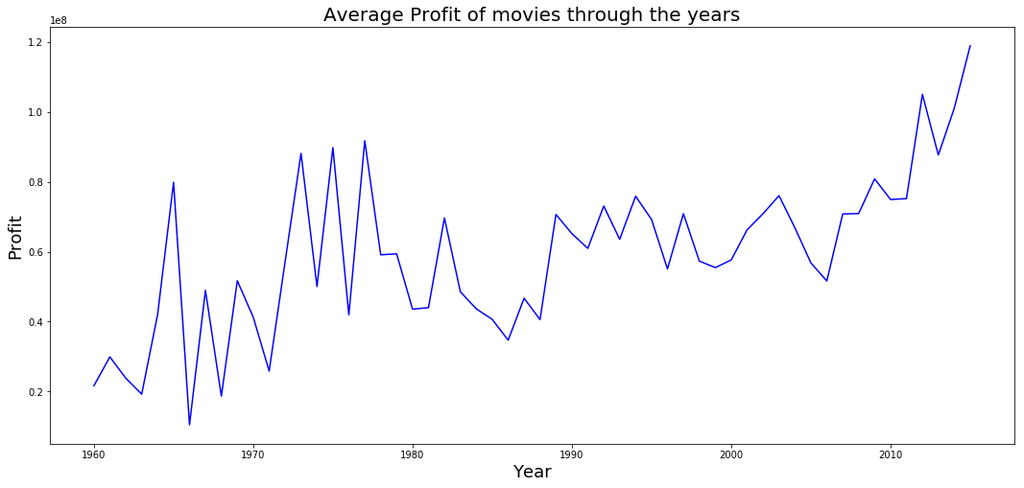

```python
df.groupby('release_year')['profit'].mean().plot(kind = 'line', figsize = (18, 8), color = 'b')
plt.title('Average Profit of movies through the years', fontsize = 20)
plt.xlabel('Year', fontsize = 18)
plt.ylabel('Profit', fontsize = 18)
```

### What variables affect the revinue of a movie the most?

```python
#To know what variables have an effect on the revenue we can find the correlation between the variables:
df.corr()
```

|  | profit | id | popularity | budget | revenue | runtime | vote_count | vote_average | release_year |
| --- | --- | --- | --- | --- | --- | --- | --- | --- | --- |
| profit | 1.000000 | 0.003934 | 0.596201 | 0.526818 | 0.979133 | 0.220238 | 0.728348 | 0.259435 | 0.087971 |
| id | 0.003934 | 1.000000 | 0.188878 | -0.027449 | -0.003206 | -0.035688 | 0.111470 | -0.001269 | 0.489926 |
| popularity | 0.596201 | 0.188878 | 1.000000 | 0.446987 | 0.615535 | 0.215092 | 0.780096 | 0.317866 | 0.173278 |
| budget | 0.526818 | -0.027449 | 0.446987 | 1.000000 | 0.688556 | 0.260977 | 0.556937 | 0.024169 | 0.268040 |
| revenue | 0.979133 | -0.003206 | 0.615535 | 0.688556 | 1.000000 | 0.250298 | 0.754567 | 0.227123 | 0.139140 |
| runtime | 0.220238 | -0.035688 | 0.215092 | 0.260977 | 0.250298 | 1.000000 | 0.273771 | 0.351712 | -0.112453 |
| vote_count | 0.728348 | 0.111470 | 0.780096 | 0.556937 | 0.754567 | 0.273771 | 1.000000 | 0.387210 | 0.207191 |
| vote_average | 0.259435 | -0.001269 | 0.317866 | 0.024169 | 0.227123 | 0.351712 | 0.387210 | 1.000000 | -0.134246 |
| release_year | 0.087971 | 0.489926 | 0.173278 | 0.268040 | 0.139140 | -0.112453 | 0.207191 | -0.134246 | 1.000000 |

From the above table, we can notice a strong correlation with popularity, budget and vote count. also we can see there is a Weak correlation between the revenue and the runtime of the movie

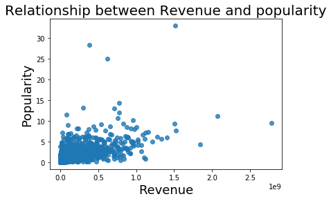

```python
#We can visulaize the above correlation relationship using a scatter plot:
sns.regplot(x = df['revenue'], y = df['popularity'], fit_reg = False)

fig_size = plt.rcParams["figure.figsize"]
fig_size[0] = 16
fig_size[1] = 8

plt.rcParams["figure.figsize"] = fig_size
plt.title('Relationship between Revenue and popularity', fontsize = 20)
plt.xlabel('Revenue', fontsize = 18)
plt.ylabel('Popularity', fontsize = 18);
```

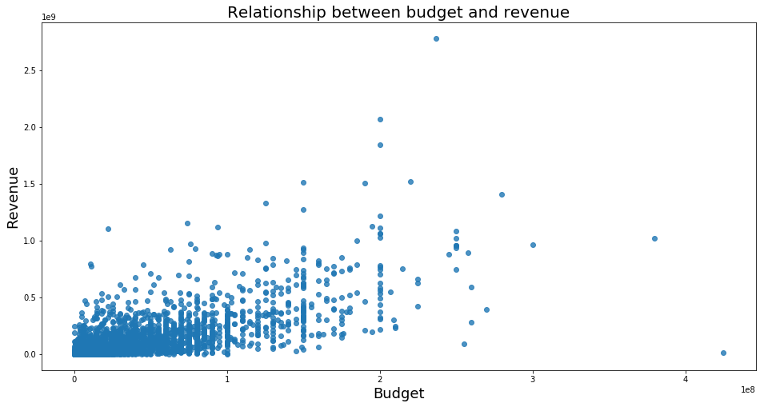

```python
sns.regplot(x = df['budget'], y = df['revenue'], fit_reg = False)
fig_size = plt.rcParams["figure.figsize"]

fig_size[0] = 16
fig_size[1] = 8
plt.rcParams["figure.figsize"] = fig_size

plt.title('Relationship between budget and revenue', fontsize = 20)
plt.xlabel('Budget', fontsize = 18)
plt.ylabel('Revenue', fontsize = 18);
```

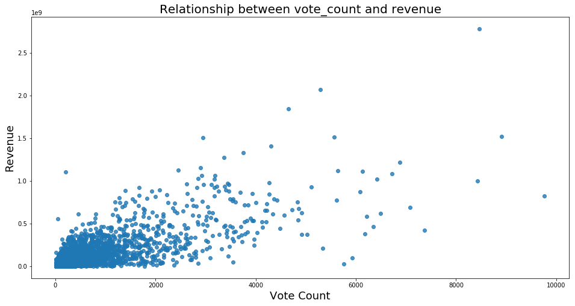

```python
sns.regplot(x = df['vote_count'], y = df['revenue'], fit_reg = False)
fig_size = plt.rcParams["figure.figsize"]

fig_size[0] = 16
fig_size[1] = 8
plt.rcParams["figure.figsize"] = fig_size

plt.title('Relationship between vote_count and revenue', fontsize = 20)
plt.xlabel('Vote Count', fontsize = 18)
plt.ylabel('Revenue', fontsize = 18);
```

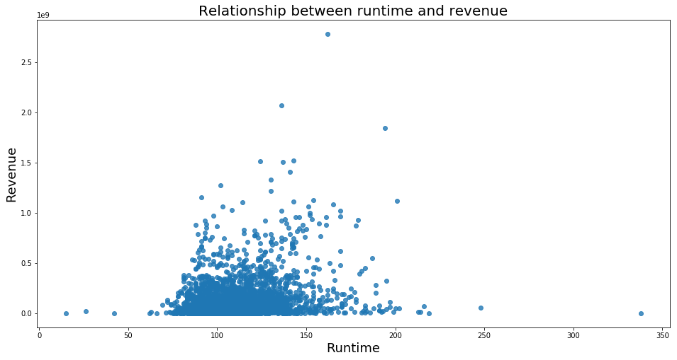

```python
sns.regplot(x = df['runtime'], y = df['revenue'], fit_reg = False)
fig_size = plt.rcParams["figure.figsize"]

fig_size[0] = 16
fig_size[1] = 8
plt.rcParams["figure.figsize"] = fig_size

plt.title('Relationship between runtime and revenue', fontsize = 20)
plt.xlabel('Runtime', fontsize = 18)
plt.ylabel('Revenue', fontsize = 18);
```

## Limitations

The data was not very clear , some columns looked ambiguous to me, such as the budget and revenue columns did not have a currency specified so there may be some differences due to fluctuating exchange rates. There might have been more variables attainable from the movies that can help give a more precise analysis such as the who was the producer or who was the writer of the movie for example. In the data wrangling phace: Rows with NaN values were dropped, hence a lot of key data might have been lost in the process, and rows with zero values were checked and because there were too much missing data in the budget and the revenue columns, I decided that I will keep them and replace the Zero values with Null values, which may have affected the analysis result.

```python
from subprocess import call
call(['python', '-m', 'nbconvert', 'Investigate_a_Dataset.ipynb'])
```

```
0
```